# The relative popularity of programming languages between 2008 and 2018

HUYNH DO MINH PHUONG

2/28/2023

## 1. Data on tags over time

How can we tell what programming languages and technologies are used by the most people? How about what languages are growing and which are shrinking, so that we can tell which are most worth investing time in?

One excellent source of data is Stack Overflow, a programming question and answer site with more than 16 million questions on programming topics. By measuring the number of questions about each technology, we can get an approximate sense of how many people are using it. We're going to use open data from the Stack Exchange Data Explorer to examine the relative popularity of languages like R, Python, Java and Javascript have changed over time.

Each Stack Overflow question has a tag, which marks a question to describe its topic or technology. For instance, there's a tag for languages like R or Python, and for packages like ggplot2 or pandas.

We'll be working with a dataset with one observation for each tag in each year. The dataset includes both the number of questions asked in that tag in that year, and the total number of questions asked in that year.

```r
# Load libraries
library(tidyverse)
# Loading the dataset
by_tag_year <- read_csv("by_tag_year.csv")
# Inspect the dataset
str(by_tag_year)
```

```
## spc_tbl_ [40,518 x 4] (S3: spec_tbl_df/tbl_df/tbl/data.frame)
##  $ year      : num [1:40518] 2008 2008 2008 2008 2008 ...
##  $ tag       : chr [1:40518] ".htaccess" ".net" ".net-2.0" ".net-3.5" ...
##  $ number    : num [1:40518] 54 5910 289 319 6 3 1 42 19 4 ...
##  $ year_total: num [1:40518] 58390 58390 58390 58390 58390 ...
##  - attr(*, "spec")=
##   .. cols(
##   ..   year = col_double(),
##   ..   tag = col_character(),
##   ..   number = col_double(),
##   ..   year_total = col_double()
##   .. )
##  - attr(*, "problems")=<externalptr>
```

*The data has 40.518 rows and 4 columns corresponding to the following information:*

*- 'year' : 10 years from 2008 to 2018,*

*- 'tag': types of programming languages in the past 10 years,*

*- 'number' : the number of questions with tag during year,*

*- 'year_toal' : total number of questions on all programming topics in the year.*

## 2. Now in fraction format

This data has one observation for each pair of a tag and a year, showing the number of questions asked in that tag in that year and the total number of questions asked in that year. For instance, there were 54 questions asked about the .htaccess tag in 2008, out of a total of 58390 questions in that year.

Rather than just the counts, we're probably interested in a percentage: the fraction of questions that year that have that tag. So let's add that to the table.

```r
library(lubridate) # Load lubridate to make dealing with dates
# Add fraction column and convert num to date
by_tag_year_fraction <- by_tag_year %>%
  mutate(fraction = number/year_total)
  #mutate(year = make_date(year))
```

```r
# Print the new table
by_tag_year_fraction
```

```
## # A tibble: 40,518 x 5
##     year tag           number year_total  fraction
##    <dbl> <chr>          <dbl>      <dbl>     <dbl>
##  1  2008 .htaccess         54      58390 0.000925
##  2  2008 .net            5910      58390 0.101
##  3  2008 .net-2.0         289      58390 0.00495
##  4  2008 .net-3.5         319      58390 0.00546
##  5  2008 .net-4.0           6      58390 0.000103
##  6  2008 .net-assembly      3      58390 0.0000514
##  7  2008 .net-core          1      58390 0.0000171
##  8  2008 2d                42      58390 0.000719
##  9  2008 32-bit            19      58390 0.000325
## 10  2008 32bit-64bit        4      58390 0.0000685
## # ... with 40,508 more rows
```

## 3. Has R been growing or shrinking?

So far we've been learning and using the R programming language. Wouldn't we like to be sure it's a good investment for the future? Has it been keeping pace with other languages, or have people been switching out of it?

Let's look at whether the fraction of Stack Overflow questions that are about R has been increasing or decreasing over time.

```r
# Filter for R tags
r_over_time <- by_tag_year_fraction %>%
  filter(tag == "r")
```

```r
# Print the new table
r_over_time
```

```
## # A tibble: 11 x 5
##     year tag   number year_total fraction
##    <dbl> <chr>  <dbl>      <dbl>    <dbl>
##  1  2008 r          8      58390 0.000137
##  2  2009 r        524     343868 0.00152
##  3  2010 r       2270     694391 0.00327
##  4  2011 r       5845    1200551 0.00487
##  5  2012 r      12221    1645404 0.00743
##  6  2013 r      22329    2060473 0.0108
##  7  2014 r      31011    2164701 0.0143
##  8  2015 r      40844    2219527 0.0184
##  9  2016 r      44611    2226072 0.0200
## 10  2017 r      54415    2305207 0.0236
## 11  2018 r      28938    1085170 0.0267
```

## 4. Visualizing change over time

Rather than looking at the results in a table, we often want to create a visualization. Change over time is usually visualized with a line plot.

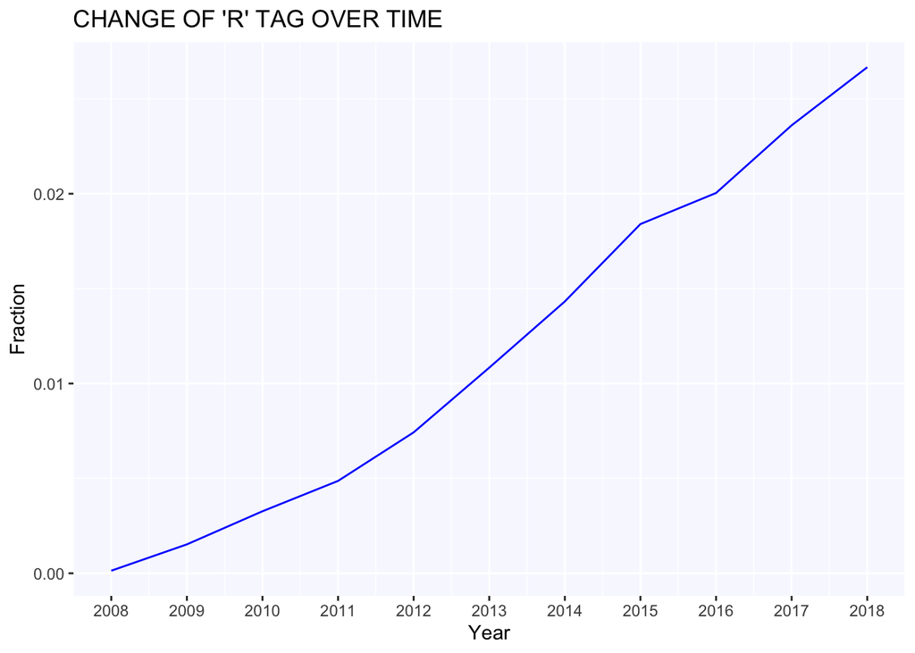

```r
# Create a line plot of fraction over time
r_over_time %>%
  ggplot(aes(year,fraction)) + geom_line(colour = "blue") +
  labs(title = "CHANGE OF 'R' TAG OVER TIME", x = "Year", y = "Fraction") +
      theme(panel.background = element_rect(fill = "GhostWhite") ) +
  scale_x_continuous(breaks = 0:2100)
```

*Interest in the R programming language has been grown rapidly over the past 10 years of the ever-increasing number of questions on this topic.*

## 5. How about dplyr and ggplot2?

Based on that graph, it looks like R has been growing pretty fast in the last decade. Good thing we're practicing it now!

Besides R, two other interesting tags are dplyr and ggplot2, which we've already used in this analysis. They both also have Stack Overflow tags!

Instead of just looking at R, let's look at all three tags and their change over time. Are each of those tags increasing as a fraction of overall questions? Are any of them decreasing?

```r
# A vector of selected tags
selected_tags <- c("r", "dplyr","ggplot2")
```

```r
# Filter for those tags
selected_tags_over_time <- by_tag_year_fraction %>%
    filter(tag %in% selected_tags)
```

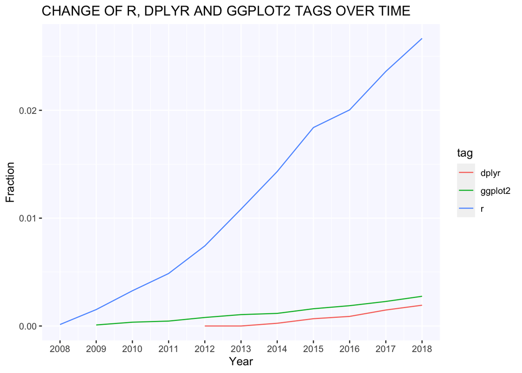

```r
# Plot tags over time on a line plot using color to represent tag
selected_tags_over_time %>%
  ggplot(aes(year,fraction,color = tag)) + geom_line() +
  labs(
    title = "CHANGE OF R, DPLYR AND GGPLOT2 TAGS OVER TIME", x = "Year", y = "Fraction") +
    theme(panel.background = element_rect(fill = "GhostWhite") ) +
  scale_x_continuous(breaks = 0:2100)
```

*R has grown quite rapidly over the last decade while later languages like dplyr and ggplot2 have a slight increase.*

## 6. What are the most asked-about tags?

It's sure been fun to visualize and compare tags over time. The dplyr and ggplot2 tags may not have as many questions as R, but we can tell they're both growing quickly as well.

We might like to know which tags have the most questions overall, not just within a particular year. Right now, we have several rows for every tag, but we'll be combining them into one. That means we want group_by() and summarize().

Let's look at tags that have the most questions in history.

```r
# Find total number of questions for each tag
sorted_tags <- by_tag_year %>%
  group_by(tag) %>%
  summarize(number_total = sum(number)) %>%
  arrange(desc(number_total))
```

```r
# Print the new table
sorted_tags
```

```
## # A tibble: 4,080 x 2
##    tag        number_total
##    <chr>             <dbl>
##  1 javascript      1632049
##  2 java            1425961
##  3 c#              1217450
##  4 php             1204291
##  5 android         1110261
##  6 python           970768
##  7 jquery           915159
##  8 html             755341
##  9 c++              574263
## 10 ios              566075
## # ... with 4,070 more rows
```

## 7. How have large programming languages changed over time?

We've looked at selected tags like R, ggplot2, and dplyr, and seen that they're each growing. What tags might be shrinking? A good place to start is to plot the tags that we just saw that were the most-asked about of all time, including JavaScript, Java and C#.

```r
# Get the six largest tags
highest_tags <- head(sorted_tags$tag)
```

```r
# Filter for the six largest tags
by_highest_tag_subset <- by_tag_year_fraction %>%
    filter(tag %in% highest_tags)
by_highest_tag_subset
```

```
## # A tibble: 66 x 5
##     year tag        number year_total fraction
##    <dbl> <chr>       <dbl>      <dbl>    <dbl>
##  1  2008 android        38      58390 0.000651
##  2  2008 c#           7473      58390 0.128
##  3  2008 java         4315      58390 0.0739
##  4  2008 javascript   2736      58390 0.0469
##  5  2008 php          2254      58390 0.0386
##  6  2008 python       2080      58390 0.0356
##  7  2009 android      1991     343868 0.00579
##  8  2009 c#          46044     343868 0.134
##  9  2009 java        24023     343868 0.0699
## 10  2009 javascript  18722     343868 0.0544
## # ... with 56 more rows
```

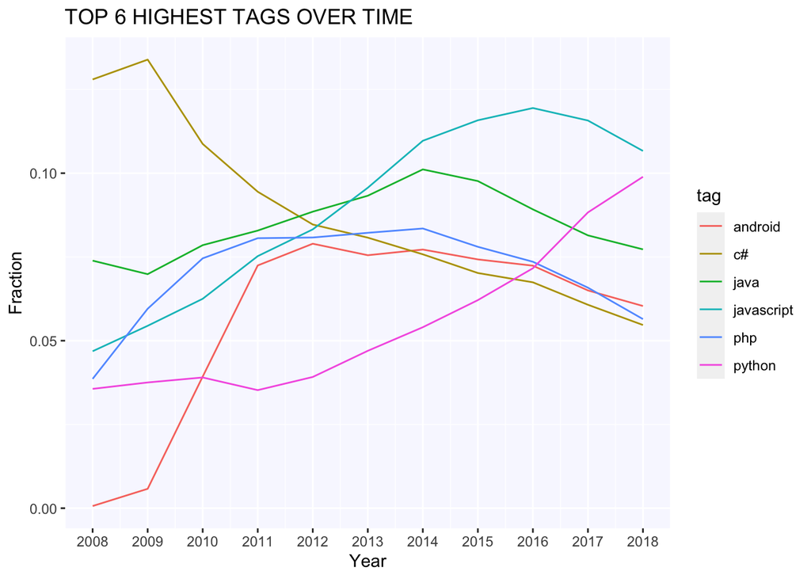

```r
# Plot tags over time on a line plot using color to represent tag
by_highest_tag_subset %>%
  ggplot(aes(year,fraction,color = tag)) + geom_line() +
  labs(
    title = "TOP 6 HIGHEST TAGS OVER TIME", x = "Year", y = "Fraction") +
    theme(panel.background = element_rect(fill = "GhostWhite") ) +
  scale_x_continuous(breaks = 0:2100)
```

*In the top 6 highest tags, python is the only asked tag that has steadily increased over the past decade, whereas c# is in a serious decline about number of questions. android, java and php rose sharply in the first 6 years and gradually decrease in the last 4 years, while javascript tended to reduce in the last 2 years after a strong increase from 2008.*

## 8. Some more tags!

Wow, based on that graph we've seen a lot of changes in what programming languages are most asked about. C# gets fewer questions than it used to, and Python has grown quite impressively.

This Stack Overflow data is incredibly versatile. We can analyze any programming language, web framework, or tool where we'd like to see their change over time. Combined with the reproducibility of R and its libraries, we have ourselves a powerful method of uncovering insights about technology.

To demonstrate its versatility, let's check out how three big mobile operating systems (Android, iOS, and Windows Phone) have compared in popularity over time. But remember: this code can be modified simply by changing the tag names!

```r
# Get tags of interest
my_tags <- c("android", "ios", "windows-phone" )
```

```r
# Filter for those tags
by_tag_subset <- by_tag_year_fraction %>%
  filter(tag %in% my_tags)
by_tag_subset
```

```
## # A tibble: 32 x 5
##     year tag           number year_total  fraction
##    <dbl> <chr>          <dbl>      <dbl>     <dbl>
##  1  2008 android           38      58390 0.000651
##  2  2008 ios               95      58390 0.00163
##  3  2008 windows-phone      1      58390 0.0000171
##  4  2009 android         1991     343868 0.00579
##  5  2009 ios              615     343868 0.00179
##  6  2010 android        27280     694391 0.0393
##  7  2010 ios             3748     694391 0.00540
##  8  2010 windows-phone     47     694391 0.0000677
##  9  2011 android        86987    1200551 0.0725
## 10  2011 ios            33214    1200551 0.0277
## # ... with 22 more rows
```

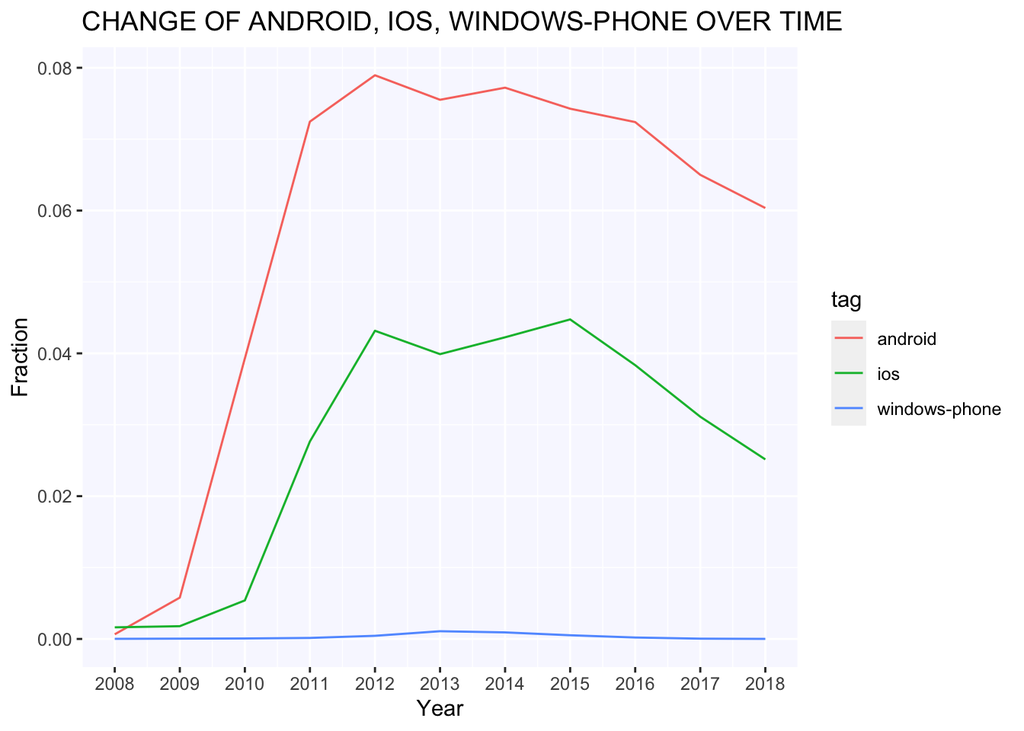

```r
# Plot tags over time on a line plot using color to represent tag
by_tag_subset %>%
  ggplot(aes(year,fraction,color = tag)) + geom_line() +
  labs(
    title = "CHANGE OF ANDROID, IOS, WINDOWS-PHONE OVER TIME", x = "Year", y = "Fraction") +
    theme(panel.background = element_rect(fill = "GhostWhite") ) +
  scale_x_continuous(breaks = 0:2100)
```

# BONUS

## 9. Has 'R' been growing or shrinking?

```r
# Filter for R tags
r_programming <- by_tag_year_fraction %>%
  filter(str_detect(tag, "^r\\b")) %>%
  group_by(year) %>%
  summarize(fraction_total = sum(fraction))
```

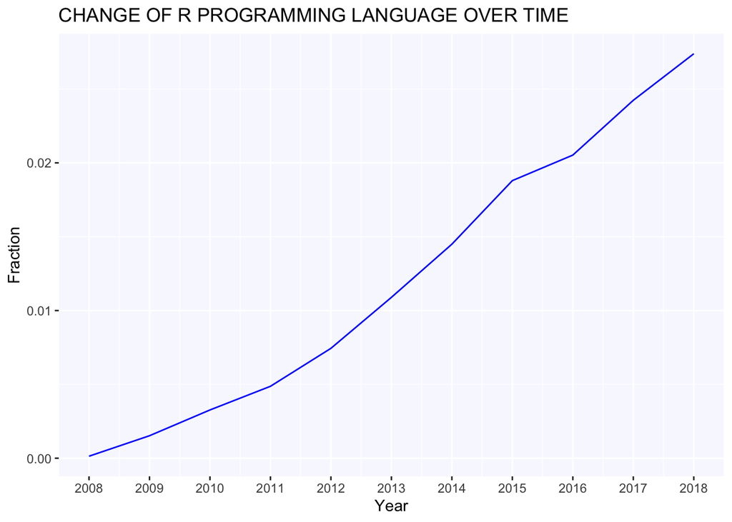

```r
# Create a line plot of fraction over time
r_programming %>%
  ggplot(aes(year,fraction_total)) + geom_line(colour = "blue") +
  labs(
    title = "CHANGE OF R PROGRAMMING LANGUAGE OVER TIME", x = "Year", y = "Fraction") +
    theme(panel.background = element_rect(fill = "GhostWhite") ) +
  scale_x_continuous(breaks = 0:2100)
```

## 10. How about three big mobile operating systems (Android, iOS, and Windows Phone)

```r
android <- by_tag_year_fraction %>%
  filter(str_detect(tag, "^android\\b")) %>%
  group_by(year) %>%
  summarize(android = sum(fraction))

ios <- by_tag_year_fraction %>%
  filter(str_detect(tag, "^ios\\b")) %>%
  group_by(year) %>%
  summarize(ios = sum(fraction))

winphone <- by_tag_year_fraction %>%
  filter(str_detect(tag, "^windows-phone\\b")) %>%
  group_by(year) %>%
  summarize(winphone = sum(fraction))

android_ios <- merge(android, ios, by="year", sort =F, all.x= T)

mobile_os <- merge(android_ios, winphone, by="year", sort=F, all.x=T) %>%
  gather(tag, total_fraction, android:winphone)
```

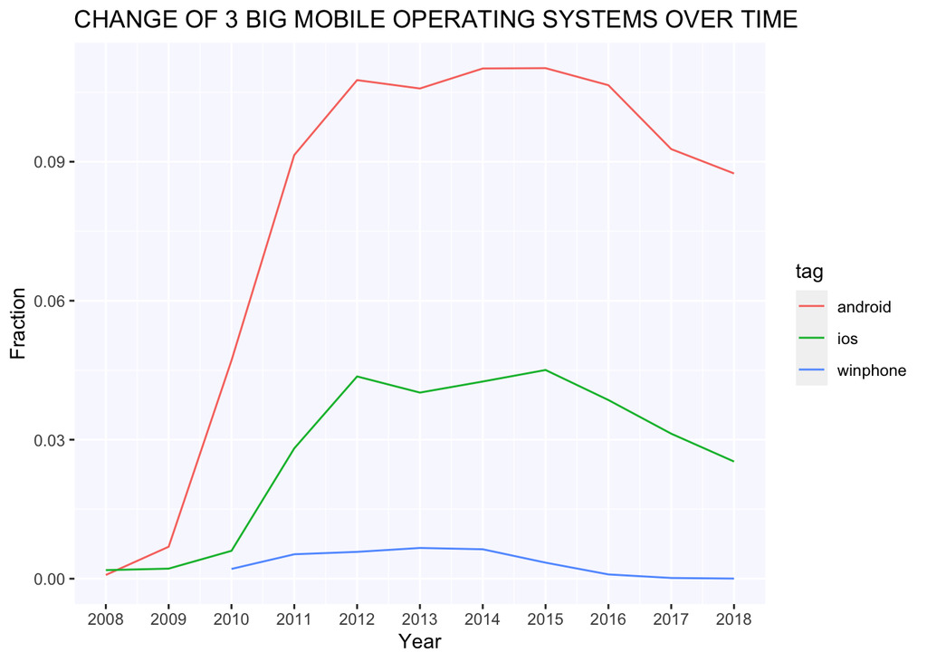

```r
# Plot tags over time on a line plot using color to represent tag
mobile_os %>%
  ggplot(aes(year,total_fraction,color = tag)) + geom_line() +
  labs(
    title = "CHANGE OF 3 BIG MOBILE OPERATING SYSTEMS OVER TIME", x = "Year", y = "Fraction") +
    theme(panel.background = element_rect(fill = "GhostWhite") ) +
  scale_x_continuous(breaks = 0:2100)
```

*There are no questions regarding the Windows Phone tag in 2009.*

## 11. How have top programming languages changed since 2014?

```r
# Filter for the tags since 2014 with fraction over 0.05
by_tag_top <- by_tag_year_fraction %>%
  filter(year >= 2014, fraction > 0.05) %>%
  arrange(desc(fraction))
```

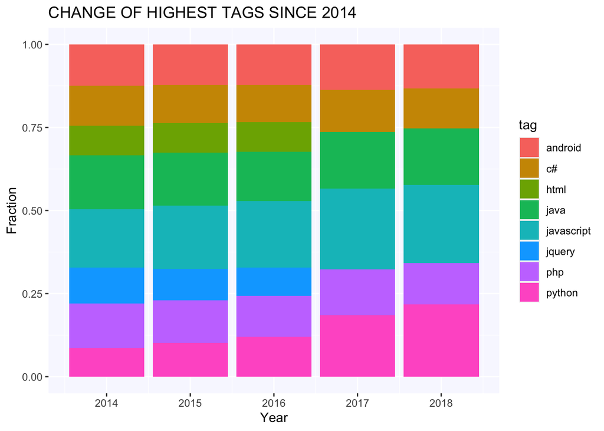

```r
library(gcookbook) # Load gcookbook for the cabbage_exp data set
# Plot tags over time on a stacked bar graph using color to selected tags
  ggplot(by_tag_top, aes(year, fraction, fill = tag)) +
  #geom_col() +
  geom_col(position = "fill") +
  labs(title = "CHANGE OF HIGHEST TAGS SINCE 2014", x = "Year", y = "Fraction") +
    theme(panel.background = element_rect(fill = "GhostWhite") ) +
  scale_x_continuous(breaks = 0:2100)
```

# 12. How has average fraction of tag changed since 2014?

```r
# Filter for the tags since 2014 and count the tag
filter_1 <- by_tag_year_fraction %>%
  filter(year >= 2014) %>%
  group_by(tag)

filter_2 <- by_tag_year_fraction %>%
  filter(year >= 2014) %>%
  count(tag)

by_tag_year_filter <- merge(filter_1, filter_2, by="tag", sort=F, all.x=T)
```

```r
filter_top <- by_tag_year_filter %>%
  group_by(tag) %>%
  summarize(avg = sum(fraction)/mean(n)) %>%
  filter(avg >= 0.05) %>%
  arrange(desc(avg))
```

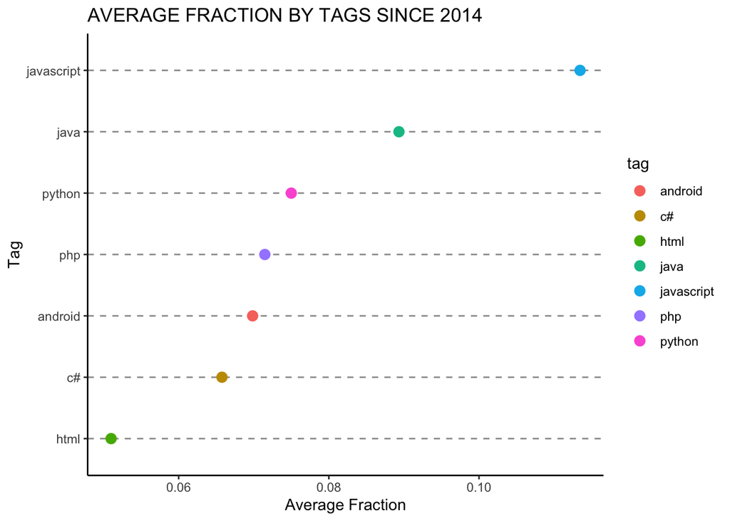

```r
# Plot tags over time on a Cleveland dot plot to filtered tags
ggplot(filter_top, aes(x = avg, y = reorder(tag, avg), col = tag)) +
  geom_point(size = 3) +  # Use a larger dot
  theme_classic () +
  theme(panel.grid.major.y = element_line(colour = "grey60", linetype = "dashed")) +
  labs(title = "AVERAGE FRACTION BY TAGS SINCE 2014", x = "Average Fraction", y = "Tag")
```

*Since 2014, the popularity of languages like Javascript and Java are still the most, whereas the number of people using c# and html is shrinking.*